# HEPSIM Evaluation Task - GSOC 2026

**Name**: Akhil Makarand Vaidya

## Summary

This notebook presents a complete analysis pipeline for quark-gluon jet discrimination using the Pythia 8 QG Jets dataset. Five QG_jets_*.npz files are loaded, yielding 500,000 jets in total, 250,000 quark (y=1) and 250,000 gluon (y=0) with constituent four-vectors stored as $(p_T, y, \varphi, \text{pdgid})$ tuples. Each file pads jets to a fixed maximum multiplicity per file; real constituents are recovered by masking on $p_T > 0$ prior to all downstream computations.

**Data exploration**

- Gluon jets contain substantially more constituents on average than quark jets, with a Wasserstein distance of approximately 19.7 between the two multiplicity distributions. This is a strong indicator of the dominant role multiplicity plays in classification.
- The leading constituent $p_T$ and $\eta$ distributions are also examined; quark jets show a dominant leading fragment.

**Jet observables**

Constituent four-momenta $(E, p_x, p_y, p_z)$ are reconstructed from $(p_T, y, \varphi)$ . Three jet-level observables are computed:

- **Invariant mass:** obtained from the summed jet four-momentum $P_J^\mu$; gluon jets have a broader mass distribution due to wider angular radiation.
- **Jet width:** $p_T$-weighted mean $\Delta R$ from the jet axis; gluon-to-quark ratio of mean widths exceeds 1, indicating gluon jets are broader on average.
- **$p_T$ dispersion ($p_T^D$):** quark jets score higher, reflecting stronger, more concentrated energy deposits.

Fisher discriminant separations are computed for all three observables to quantify their individual discriminating power before any multivariate analysis.

**Rest-frame boost**

**Classification**

Seven rest-frame features are used as classifier inputs: constituent multiplicity $N$, invariant mass $m_J$, rest-frame width, rest-frame $p_T^D$, sphericity, aplanarity, and leading energy fraction $z_\text{max}$. The dataset is split 80/20 into train and test sets with stratification. Four classifiers are trained and evaluated:

- **Gradient Boosting** (256 estimators, depth 4): AUC $\approx 0.865$
- **Random Forest** (512 estimators, depth 6): AUC $\approx 0.859$
- **Logistic Regression** (L-BFGS, C=1): AUC $\approx 0.851$
- **MLP** (architecture 64-32-16, ReLU, Adam): AUC $\approx 0.866$

Constituent multiplicity is the single most discriminating feature with a univariate AUC of approximately 0.800, consistent with it encoding the dominant physical effect. Feature importance analysis via both per-feature AUC ranking and GBT impurity-based importances agree on this ordering. Parallel classifiers trained on five equivalent lab-frame features (multiplicity, mass, lab-frame width, $p_T^D$, $z_\text{max}$) yield AUC scores within 0.02 of their rest-frame counterparts across all model classes. This confirms that, for hand-engineered scalar features, the frame choice is immaterial. All features used are either Lorentz-invariant or reduce to invariant combinations, so the boost carries no additional information into the classifier inputs.

```python
## Importing libraries

import math
import numpy as np
import matplotlib.pyplot as plt
from pathlib import Path
from scipy import stats
from sklearn.model_selection import train_test_split
from sklearn.preprocessing import StandardScaler
from sklearn.ensemble import GradientBoostingClassifier, RandomForestClassifier
from sklearn.linear_model import LogisticRegression
from sklearn.metrics import (roc_auc_score, accuracy_score, f1_score, precision_score, recall_score, roc_curve)
from sklearn.metrics import roc_curve
from sklearn.metrics import confusion_matrix, ConfusionMatrixDisplay

import time
import warnings
warnings.filterwarnings('ignore')

np.random.seed(42)
plt.style.use('seaborn-v0_8')

QUARK_COLOR = 'steelblue'
GLUON_COLOR = 'tomato'
DATA_DIR = Path('../data')


TEST_SIZE   = 0.20
RANDOM_SEED = 42
```

**Dataset Information**

I've used the following five dataset files (.npz). The code assumes these files are located in a /data directory.

```
├── data/
│   ├── QG_jets_1.npz
│   ├── QG_jets_2.npz
│   ├── QG_jets_3.npz
│   ├── QG_jets_4.npz
│   └── QG_jets_5.npz
└── notebooks/
    └── QG_Analysis.ipynb
```

The files are downloaded from: [Pythia8 Quark and Gluon Jets for Energy Flow Dataset](https://zenodo.org/records/3164691)

```python
## loading one file and check structure

sample = np.load(DATA_DIR / 'QG_jets_1.npz', allow_pickle=True)
print("Keys:", list(sample.keys()))
print("X shape:", sample['X'].shape)
print("y shape:", sample['y'].shape)
print("X dtype:", sample['X'].dtype)

# print("Sample jet [0], first 5 rows:")
# print(sample['X'][0][:5])
# print("Label:", sample['y'][0])

jet0 = sample['X'][0]
n_total = len(jet0)
n_real = np.sum(jet0[:, 0] > 0)
print(f"Jet 0: {n_total} total rows, {n_real} real constituents, {n_total - n_real} zero-padded")
```

```
Keys: ['X', 'y']
X shape: (100000, 134, 4)
y shape: (100000,)
X dtype: float64
Jet 0: 134 total rows, 74 real constituents, 60 zero-padded
```

```python
## cleaning and aggregating data from 5 files

def load_jets(filepath):
    """Load jets and labels from a .npz file."""
    data = np.load(filepath, allow_pickle=True)
    return data['X'], data['y']

def remove_padding(jet):
    """Remove zero-padded rows. A constituent is real if pT > 0 (column 0)."""
    return jet[jet[:, 0] > 0]

files = sorted(DATA_DIR.glob('QG_jets_*.npz'))

all_X, all_y = [], []
for f in files:
    Xi, yi = load_jets(f)
    all_X.append(Xi)
    all_y.append(yi)
    print(f"{f.name}: {len(Xi)} jets, shape={Xi.shape}")

max_rows = max(arr.shape[1] for arr in all_X)
if any(arr.shape[1] != max_rows for arr in all_X):
    padded_X = []
    for arr in all_X:
        if arr.shape[1] < max_rows:
            pad_width = ((0, 0), (0, max_rows - arr.shape[1]), (0, 0))
            arr_p = np.pad(arr, pad_width, mode='constant', constant_values=0.0)
            padded_X.append(arr_p)
        else:
            padded_X.append(arr)
    all_X = padded_X

X = np.concatenate(all_X, axis=0)
y = np.concatenate(all_y, axis=0)
assert len(X) == len(y)

print(f"\nTotal jets: {len(X)}")
print(f"Quark jets (y=1): {np.sum(y == 1)}")
print(f"Gluon jets (y=0): {np.sum(y == 0)}")
```

```
QG_jets_1.npz: 100000 jets, shape=(100000, 134, 4)
QG_jets_2.npz: 100000 jets, shape=(100000, 132, 4)
QG_jets_3.npz: 100000 jets, shape=(100000, 128, 4)
QG_jets_4.npz: 100000 jets, shape=(100000, 136, 4)
QG_jets_5.npz: 100000 jets, shape=(100000, 136, 4)

Total jets: 500000
Quark jets (y=1): 250000
Gluon jets (y=0): 250000
```

```python
## identifying total number of constituents in quark vs gluon jets (actual constituents)

def count_constituents(jet):
    """Return number of real (non-padded) constituents."""
    return np.sum(jet[:, 0] > 0)

multiplicities = np.array([count_constituents(j) for j in X])
quark_mult = multiplicities[y == 1]
gluon_mult = multiplicities[y == 0]

print(f"Total constituents in quark jets: {int(quark_mult.sum())}")
print(f"Total constituents in gluon jets: {int(gluon_mult.sum())}")
print(f"Quark mean: {quark_mult.mean():.2f}, std: {quark_mult.std():.2f}, min: {quark_mult.min()}, max: {quark_mult.max()}, median: {np.median(quark_mult):.0f}")
print(f"Gluon mean: {gluon_mult.mean():.2f}, std: {gluon_mult.std():.2f}, min: {gluon_mult.min()}, max: {gluon_mult.max()}, median: {np.median(gluon_mult):.0f}")
```

```
Total constituents in quark jets: 8350222
Total constituents in gluon jets: 13283118
Quark mean: 33.40, std: 13.27, min: 1, max: 129, median: 31
Gluon mean: 53.13, std: 15.67, min: 2, max: 136, median: 52
```

```
Wasserstein distance: 19.732
```

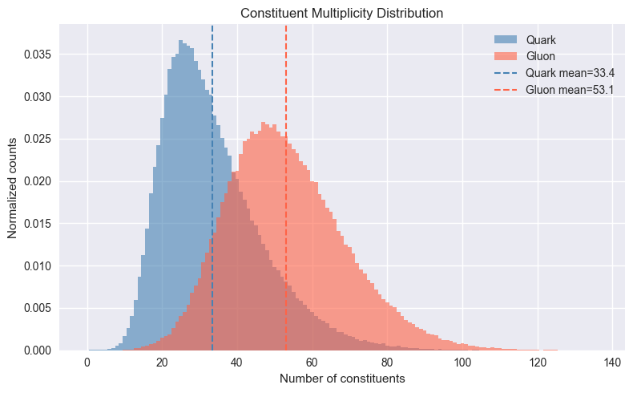

```python
## Histogram plot of multiplicity on the common axis

fig, ax = plt.subplots(figsize=(8, 5))
bins = np.arange(0, multiplicities.max() + 2) - 0.5

# Useing density=True here to compare the shapes of distributions independent of sample size.

ax.hist(quark_mult, bins=bins, density=True, alpha=0.6, color=QUARK_COLOR, label='Quark')
ax.hist(gluon_mult, bins=bins, density=True, alpha=0.6, color=GLUON_COLOR, label='Gluon')
ax.axvline(quark_mult.mean(), color=QUARK_COLOR, ls='--', lw=1.5,
           label=f'Quark mean={quark_mult.mean():.1f}')
ax.axvline(gluon_mult.mean(), color=GLUON_COLOR, ls='--', lw=1.5,
           label=f'Gluon mean={gluon_mult.mean():.1f}')
ax.set_xlabel('Number of constituents')
ax.set_ylabel('Normalized counts')
ax.set_title('Constituent Multiplicity Distribution')
ax.legend()
fig.tight_layout()

wd = stats.wasserstein_distance(quark_mult, gluon_mult)
print(f"Wasserstein distance: {wd:.3f}")
plt.show()
```

```
pT  Quark: mean=148.83, std=71.39
pT  Gluon: mean=90.57, std=43.52
eta Quark: mean=0.0017, std=0.86
eta Gluon: mean=-0.0011, std=0.89
```

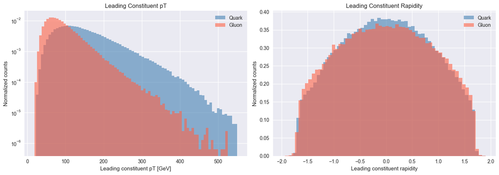

```python
## Leading constituent pT and eta distributions

def get_leading(jet):
    """Return the leading (highest pT) constituent after removing padding."""
    real = remove_padding(jet)
    return real[np.argmax(real[:, 0])]

leading = np.array([get_leading(j) for j in X])
lead_pt_q = leading[y == 1, 0]
lead_pt_g = leading[y == 0, 0]
lead_eta_q = leading[y == 1, 1]
lead_eta_g = leading[y == 0, 1]

print(f"pT  Quark: mean={lead_pt_q.mean():.2f}, std={lead_pt_q.std():.2f}")
print(f"pT  Gluon: mean={lead_pt_g.mean():.2f}, std={lead_pt_g.std():.2f}")
print(f"eta Quark: mean={lead_eta_q.mean():.4f}, std={lead_eta_q.std():.2f}")
print(f"eta Gluon: mean={lead_eta_g.mean():.4f}, std={lead_eta_g.std():.2f}")

fig, axes = plt.subplots(1, 2, figsize=(14, 5))

ax = axes[0]
ax.hist(lead_pt_q, bins=80, density=True, alpha=0.6, color=QUARK_COLOR, label='Quark')
ax.hist(lead_pt_g, bins=80, density=True, alpha=0.6, color=GLUON_COLOR, label='Gluon')
ax.set_yscale('log')
ax.set_xlabel('Leading constituent pT [GeV]')
ax.set_ylabel('Normalized counts')
ax.set_title('Leading Constituent pT')
ax.legend()

ax = axes[1]
ax.hist(lead_eta_q, bins=60, density=True, alpha=0.6, color=QUARK_COLOR, label='Quark')
ax.hist(lead_eta_g, bins=60, density=True, alpha=0.6, color=GLUON_COLOR, label='Gluon')
ax.set_xlabel('Leading constituent rapidity')
ax.set_ylabel('Normalized counts')
ax.set_title('Leading Constituent Rapidity')
ax.legend()

fig.tight_layout()
plt.show()
```

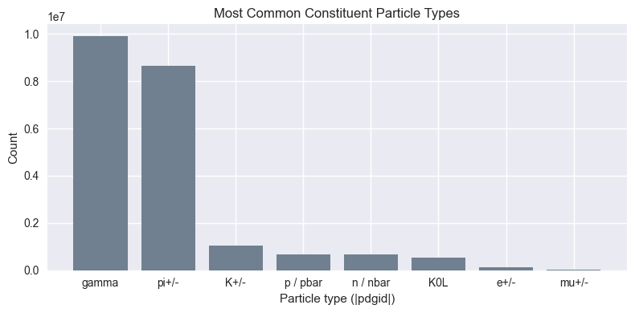

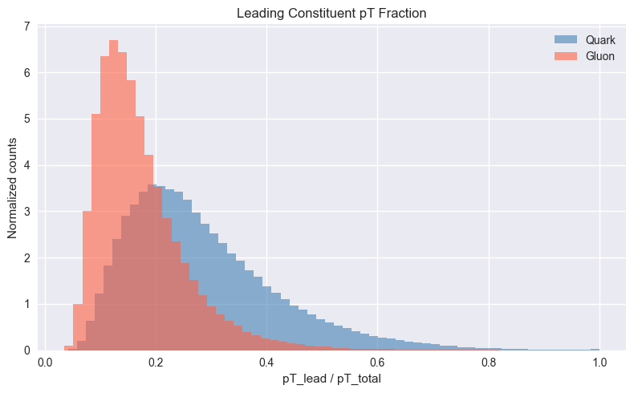

```python
## To observe the most common particle types in the jets, we can look at the distribution of PDG IDs among the constituents.
## I've refered this doc: https://pdg.lbl.gov/2007/reviews/montecarlorpp.pdf


pdgid_lookup = {
    11: 'e+/-',       # electron / positron
    13: 'mu+/-',      # muon / antimuon
    22: 'gamma',      # photon
    211:'pi+/-',      # charged pion
    310:'K0S',        # short kaon
    130:'K0L',        # long kaon
    321:'K+/-',       # charged kaon
    2212:'p / pbar',  # proton / antiproton
    2112:'n / nbar',  # neutron / antineutron
}

all_pdg = np.concatenate([np.abs(remove_padding(j)[:, 3]).astype(int) for j in X])
unique, counts = np.unique(all_pdg, return_counts=True)
order = np.argsort(-counts)[:10]

fig, ax = plt.subplots(figsize=(8, 4))
labels_pdg = [pdgid_lookup.get(int(unique[i]), str(int(unique[i]))) for i in order]
ax.bar(labels_pdg, counts[order], color='slategray')
ax.set_xlabel('Particle type (|pdgid|)')
ax.set_ylabel('Count')
ax.set_title('Most Common Constituent Particle Types')
fig.tight_layout()
plt.show()

## observing the fraction of jet pT carried by the leading constituent

pt_frac_q, pt_frac_g = [], []
for i, jet in enumerate(X):
    real = remove_padding(jet)
    pt_sum = real[:, 0].sum()
    frac = real[:, 0].max() / pt_sum if pt_sum > 0 else 0
    (pt_frac_q if y[i] == 1 else pt_frac_g).append(frac)

fig, ax = plt.subplots(figsize=(8, 5))
ax.hist(pt_frac_q, bins=60, density=True, alpha=0.6, color=QUARK_COLOR, label='Quark')
ax.hist(pt_frac_g, bins=60, density=True, alpha=0.6, color=GLUON_COLOR, label='Gluon')
ax.set_xlabel('pT_lead / pT_total')
ax.set_ylabel('Normalized counts')
ax.set_title('Leading Constituent pT Fraction')
ax.legend()
fig.tight_layout()
plt.show()
```

## Task B: Jet Observables

```python
## functions for four momentum calculations

def get_four_momenta(jet):
    """Convert all real constituents (pT, y, phi, pdgid) to (E, px, py, pz).
    Uses massless approximation: E = pT * cosh(y).
    Returns (N, 4) array.
    """
    real = remove_padding(jet)
    pt, rap, phi = real[:, 0], real[:, 1], real[:, 2]
    px = pt * np.cos(phi)
    py = pt * np.sin(phi)
    pz = pt * np.sinh(rap)
    E = pt * np.cosh(rap)
    return np.column_stack([E, px, py, pz])

def jet_four_momentum(jet):
    """Sum four-momenta of all real constituents. Returns (E, px, py, pz)."""
    return get_four_momenta(jet).sum(axis=0)

# Sanity check
p4 = jet_four_momentum(X[0])
E, px, py, pz = p4
p_mag = np.sqrt(px**2 + py**2 + pz**2)
print(f"Jet 0 four-momentum: E={E:.2f}, px={px:.2f}, py={py:.2f}, pz={pz:.2f}")
print(f"|p| = {p_mag:.2f},  E > |p|: {E > p_mag}")
```

```
Jet 0 four-momentum: E=985.55, px=180.88, py=-489.71, pz=-833.50
|p| = 983.50,  E > |p|: True
```

```
Jet Mass [GeV]
Quark mean: 32.14, std: 18.80, median: 26.16, min: 0.00, max: 140.28
Gluon mean: 46.86, std: 20.73, median: 41.89, min: 3.44, max: 140.74
```

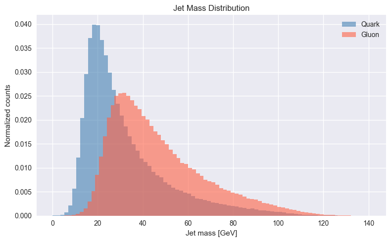

```python
## Computing jet mass using the invariant mass

def jet_mass(jet):
    """Compute invariant mass: m = sqrt(E^2 - |p|^2)."""
    E, px, py, pz = jet_four_momentum(jet)
    m2 = E**2 - px**2 - py**2 - pz**2
    return np.sqrt(max(m2, 0.0))

masses = np.array([jet_mass(j) for j in X])
mass_q = masses[y == 1]
mass_g = masses[y == 0]

print("Jet Mass [GeV]")
print(f"Quark mean: {mass_q.mean():.2f}, std: {mass_q.std():.2f}, median: {np.median(mass_q):.2f}, min: {mass_q.min():.2f}, max: {mass_q.max():.2f}")
print(f"Gluon mean: {mass_g.mean():.2f}, std: {mass_g.std():.2f}, median: {np.median(mass_g):.2f}, min: {mass_g.min():.2f}, max: {mass_g.max():.2f}")

fig, ax = plt.subplots(figsize=(8, 5))
ax.hist(mass_q, bins=80, density=True, alpha=0.6, color=QUARK_COLOR, label='Quark')
ax.hist(mass_g, bins=80, density=True, alpha=0.6, color=GLUON_COLOR, label='Gluon')
ax.set_xlabel('Jet mass [GeV]')
ax.set_ylabel('Normalized counts')
ax.set_title('Jet Mass Distribution')
ax.legend()
fig.tight_layout()
plt.show()
```

```
Jet Width
Quark mean: 0.0390, std: 0.0353
Gluon mean: 0.0653, std: 0.0409
Gluon/Quark width ratio: 1.673
```

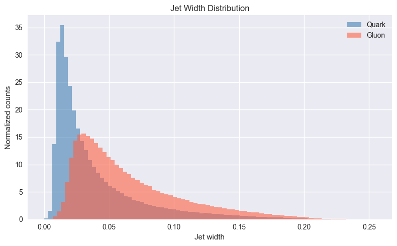

```python
## Computing and comparing the jet width

def delta_phi(phi1, phi2):
    """Delta-phi with wrapping at +/- pi."""
    dphi = phi1 - phi2
    return (dphi + np.pi) % (2 * np.pi) - np.pi

def jet_width(jet):
    """pT-weighted jet width (girth)."""
    real = remove_padding(jet)
    pt, eta, phi = real[:, 0], real[:, 1], real[:, 2]
    pt_sum = pt.sum()
    if pt_sum == 0:
        return 0.0
    eta_J = np.dot(pt, eta) / pt_sum
    phi_J = np.arctan2(np.dot(pt, np.sin(phi)), np.dot(pt, np.cos(phi)))
    dphi = delta_phi(phi, phi_J)
    deta = eta - eta_J
    dR = np.sqrt(deta**2 + dphi**2)
    return np.dot(pt, dR) / pt_sum

widths = np.array([jet_width(j) for j in X])
width_q = widths[y == 1]
width_g = widths[y == 0]

print("Jet Width")
print(f"Quark mean: {width_q.mean():.4f}, std: {width_q.std():.4f}")
print(f"Gluon mean: {width_g.mean():.4f}, std: {width_g.std():.4f}")
print(f"Gluon/Quark width ratio: {width_g.mean()/width_q.mean():.3f}")

fig, ax = plt.subplots(figsize=(8, 5))
ax.hist(width_q, bins=80, density=True, alpha=0.6, color=QUARK_COLOR, label='Quark')
ax.hist(width_g, bins=80, density=True, alpha=0.6, color=GLUON_COLOR, label='Gluon')
ax.set_xlabel('Jet width')
ax.set_ylabel('Normalized counts')
ax.set_title('Jet Width Distribution')
ax.legend()
fig.tight_layout()
plt.show()
```

Gluon / Quark ratio is > 1 indicating that gluon jets are wider on average than quark jets

```
pT Dispersion
Quark mean: 0.3826, std: 0.1130
Gluon mean: 0.2728, std: 0.0722
```

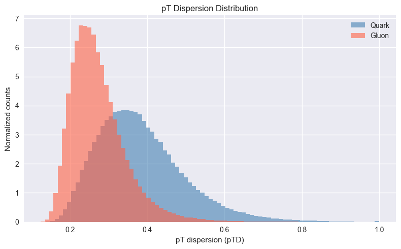

```python
## Computing and comparing the pT dispersion

def pt_dispersion(jet):
    """pT dispersion: sqrt(sum(pT_i^2)) / sum(pT_i).
    Close to 1 = one particle dominates; close to 0 = many equal-pT particles.
    """
    real = remove_padding(jet)
    pt = real[:, 0]
    pt_sum = pt.sum()
    if pt_sum == 0:
        return 0.0
    return np.sqrt(np.sum(pt**2)) / pt_sum

ptd = np.array([pt_dispersion(j) for j in X])
ptd_q = ptd[y == 1]
ptd_g = ptd[y == 0]

print("pT Dispersion")
print(f"Quark mean: {ptd_q.mean():.4f}, std: {ptd_q.std():.4f}")
print(f"Gluon mean: {ptd_g.mean():.4f}, std: {ptd_g.std():.4f}")

fig, ax = plt.subplots(figsize=(8, 5))
ax.hist(ptd_q, bins=80, density=True, alpha=0.6, color=QUARK_COLOR, label='Quark')
ax.hist(ptd_g, bins=80, density=True, alpha=0.6, color=GLUON_COLOR, label='Gluon')
ax.set_xlabel('pT dispersion (pTD)')
ax.set_ylabel('Normalized counts')
ax.set_title('pT Dispersion Distribution')
ax.legend()
fig.tight_layout()
plt.show()
```

In the case of Gluons, the dispersion if lower indicating more uniform jet constituents, while for Quarks, the dispersion is higher indicating a more dominant leading particle.

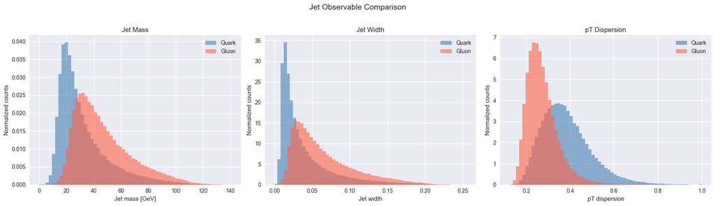

```python
## combined graph of all three observables for convenient comparison

fig, axes = plt.subplots(1, 3, figsize=(18, 5))
for ax, dq, dg, xlab, ttl in zip(
    axes,
    [mass_q, width_q, ptd_q],
    [mass_g, width_g, ptd_g],
    ['Jet mass [GeV]', 'Jet width', 'pT dispersion'],
    ['Jet Mass', 'Jet Width', 'pT Dispersion']
):
    ax.hist(dq, bins=60, density=True, alpha=0.6, color=QUARK_COLOR, label='Quark')
    ax.hist(dg, bins=60, density=True, alpha=0.6, color=GLUON_COLOR, label='Gluon')
    ax.set_xlabel(xlab)
    ax.set_ylabel('Normalized counts')
    ax.set_title(ttl)
    ax.legend()
fig.suptitle('Jet Observable Comparison', fontsize=14, y=1.02)
fig.tight_layout()
plt.show()
```

```python
## Fisher discriminant separation for each observable to see how well they separate quark vs gluon jets

for name, dq, dg in [('Mass', mass_q, mass_g), ('Width', width_q, width_g), ('pTD', ptd_q, ptd_g)]:
    sep = abs(dq.mean() - dg.mean()) / np.sqrt((dq.std()**2 + dg.std()**2) / 2)
    print(f"{name}: {sep:.3f}")
```

```
Mass: 0.744
Width: 0.688
pTD: 1.157
```

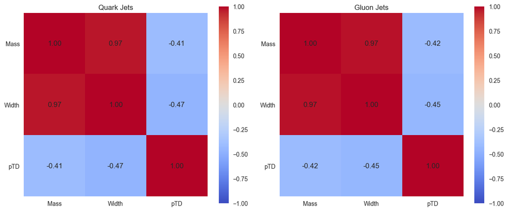

```python
# Correlation matrices

obs_labels = ['Mass', 'Width', 'pTD']
fig, axes = plt.subplots(1, 2, figsize=(12, 5))
for ax, mask, title in zip(axes, [y == 1, y == 0], ['Quark Jets', 'Gluon Jets']):
    data = np.column_stack([masses[mask], widths[mask], ptd[mask]])
    corr = np.corrcoef(data.T)
    im = ax.imshow(corr, cmap='coolwarm', vmin=-1, vmax=1)
    ax.set_xticks(range(3)); ax.set_yticks(range(3))
    ax.set_xticklabels(obs_labels); ax.set_yticklabels(obs_labels)
    ax.set_title(title)
    for i in range(3):
        for j2 in range(3):
            ax.text(j2, i, f'{corr[i, j2]:.2f}', ha='center', va='center', fontsize=12)
    plt.colorbar(im, ax=ax)
    ax.grid(False)
fig.tight_layout()
plt.show()
```

## Task C: Boost to the Jet Center-of-Mass Frame

**Boost Implementation**

The jet four-momentum is obtained by summing constituent four-momenta in the lab frame:

$$P_J^\mu = \sum_i p_i^\mu = (E_J,\, p_{x,J},\, p_{y,J},\, p_{z,J})$$

The boost vector that maps the lab frame to the jet rest frame (where $\vec{p}_J = \vec{0}$) is:

$$\vec{\beta} = \frac{\vec{p}_J}{E_J}, \qquad \gamma = \frac{1}{\sqrt{1 - |\vec{\beta}|^2}} = \frac{E_J}{m_J}$$

where $m_J = \sqrt{E_J^2 - |\vec{p}_J|^2}$ is the invariant mass of the jet. For each constituent four-momentum $(E_i, \vec{p}_i)$, the boosted quantities are computed via the standard vectorised Lorentz boost:

$$E_i' = \gamma\!\left(E_i - \vec{\beta}\cdot\vec{p}_i\right)$$

$$\vec{p}_i' = \vec{p}_i + \vec{\beta}\!\left[\frac{(\gamma-1)\,\vec{\beta}\cdot\vec{p}_i}{|\vec{\beta}|^2} - \gamma E_i\right]$$

This form avoids constructing an explicit $4\times4$ boost matrix and operates directly on the constituent arrays in a fully vectorised manner. The dot products $\vec{\beta}\cdot\vec{p}_i$ are computed as a single matrix–vector product $p_{\mathrm{3,lab}} \cdot \beta$, giving $\mathcal{O}(N)$ complexity per jet. The limit $|\vec{\beta}|\to 0$ correctly recovers the identity transformation.

```python
## Boost function to jet rest frame

def boost_to_rest_frame(jet):
    """
    Boost all real constituents of a jet from the lab frame to the jet rest frame.

    Parameters
    ----------
    jet : (N_padded, 4) array  — raw jet array with features (pT, rapidity, phi, pdgid)

    Returns
    -------
    p4_rest : (N_real, 4) array — constituent four-momenta (E, px, py, pz) in the rest frame
    beta    : (3,) array
    gamma   : float
    """
    # (N, 4): [E, px, py, pz]
    p4_lab = get_four_momenta(jet)

    P_J = p4_lab.sum(axis=0)               # (E_J, px_J, py_J, pz_J)
    E_J = P_J[0]
    p3_J = P_J[1:]                         # (px_J, py_J, pz_J)

    # boost vector and Lorentz factor
    beta  = p3_J / E_J
    beta2 = np.dot(beta, beta)
    gamma = 1.0 / np.sqrt(1.0 - beta2)

    E_lab  = p4_lab[:, 0]                  # (N,)
    p3_lab = p4_lab[:, 1:]                 # (N, 3)

    beta_dot_p = p3_lab @ beta

    E_rest  = gamma * (E_lab - beta_dot_p)
    p3_rest = p3_lab + beta[np.newaxis, :] * (
        ((gamma - 1) / beta2) * beta_dot_p[:, np.newaxis]
        - gamma * E_lab[:, np.newaxis]
    )                                                                                # (N, 3)

    p4_rest = np.column_stack([E_rest, p3_rest])   # (N, 4)
    return p4_rest, beta, gamma


# sanity print for jet 0
p4_rest_0, beta_0, gamma_0 = boost_to_rest_frame(X[0])
p_total_rest = p4_rest_0[:, 1:].sum(axis=0)
print(f"Jet 0 beta = {beta_0}")
print(f"Jet 0 gamma = {gamma_0:.4f}")
print(f"Total 3-momentum after boost: {p_total_rest}")
print(f"|Σp_rest| = {np.linalg.norm(p_total_rest):.2e}")
```

```
Jet 0 beta = [ 0.18353263 -0.49689376 -0.84572127]
Jet 0 gamma = 15.4896
Total 3-momentum after boost: [-7.54951657e-13  2.25508501e-12  3.63620245e-12]
|Σp_rest| = 4.34e-12
```

```
Residual |Σp_rest| over 500 jets:
Mean   : 2.834e-12
Std    : 4.320e-12
Max    : 4.969e-11
Median : 1.572e-12
```

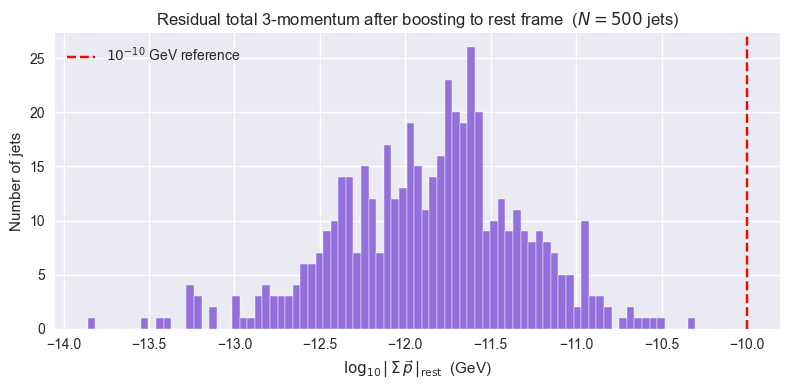

```python
## verification: total 3-momentum vanishes after boost

N_verify = 500
residuals = []

for i in range(N_verify):
    p4_rest, _, _ = boost_to_rest_frame(X[i])
    p_tot = p4_rest[:, 1:].sum(axis=0)
    residuals.append(np.linalg.norm(p_tot))

residuals = np.array(residuals)

print(f"Residual |Σp_rest| over {N_verify} jets:")
print(f"Mean   : {residuals.mean():.3e}")
print(f"Std    : {residuals.std():.3e}")
print(f"Max    : {residuals.max():.3e}")
print(f"Median : {np.median(residuals):.3e}")

fig, ax = plt.subplots(figsize=(8, 4))
ax.hist(np.log10(residuals + 1e-30), bins=80, color='mediumpurple', edgecolor='white', linewidth=0.3)
ax.set_xlabel(r'$\log_{10}|\,\Sigma\,\vec{p}\,|_\mathrm{rest}$  (GeV)')
ax.set_ylabel('Number of jets')
ax.set_title(r'Residual total 3-momentum after boosting to rest frame  ($N=500$ jets)')
ax.axvline(np.log10(1e-10), color='red', linestyle='--', label=r'$10^{-10}$ GeV reference')
ax.legend()
fig.tight_layout()
plt.show()
```

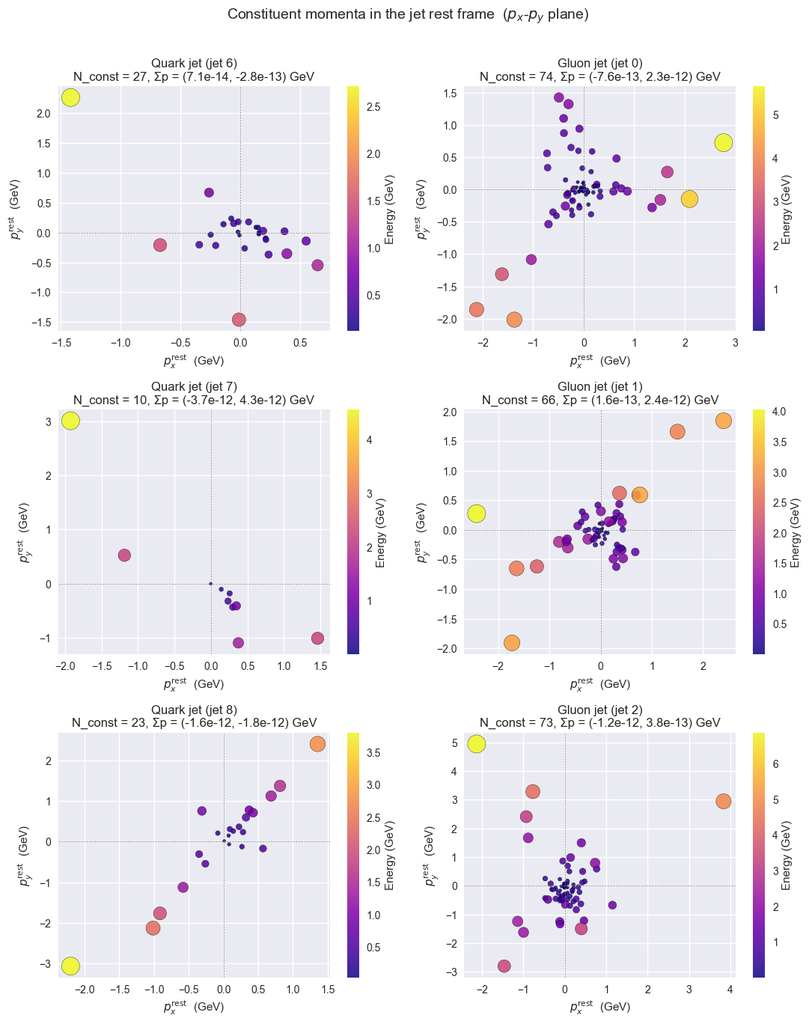

```python
## Rest-frame constituent scatter plots

quark_indices = np.where(y == 1)[0]
gluon_indices = np.where(y == 0)[0]
N_examples = 3
q_idxs = quark_indices[:N_examples]
g_idxs = gluon_indices[:N_examples]

fig, axes = plt.subplots(N_examples, 2, figsize=(11, 4.5 * N_examples))

for row, (qi, gi) in enumerate(zip(q_idxs, g_idxs)):
    for col, (idx, label, color) in enumerate([
        (qi, 'Quark jet', QUARK_COLOR),
        (gi, 'Gluon jet', GLUON_COLOR),
    ]):
        ax = axes[row, col]
        p4_rest, _, _ = boost_to_rest_frame(X[idx])

        E_rest  = p4_rest[:, 0]
        px_rest = p4_rest[:, 1]
        py_rest = p4_rest[:, 2]

        # Marker size proportional to energy
        E_norm = E_rest / E_rest.max()
        sizes  = np.clip(E_norm * 300, 8, 300)  ## clipped this to avoid tiny/huge markers

        sc = ax.scatter(px_rest, py_rest, s=sizes, c=E_rest,
                        cmap='plasma', alpha=0.85, edgecolors='k', linewidths=0.3)
        plt.colorbar(sc, ax=ax, label='Energy (GeV)')

        ax.set_xlabel(r'$p_x^\mathrm{rest}$  (GeV)')
        ax.set_ylabel(r'$p_y^\mathrm{rest}$  (GeV)')
        ax.set_title(f'{label} (jet {idx})\n'
                     f'N_const = {len(p4_rest)}, '
                     f'Σp = ({px_rest.sum():.1e}, {py_rest.sum():.1e}) GeV')
        ax.axhline(0, color='grey', lw=0.5, ls='--')
        ax.axvline(0, color='grey', lw=0.5, ls='--')

fig.suptitle(r'Constituent momenta in the jet rest frame  ($p_x$-$p_y$ plane)', fontsize=14, y=1.01)
fig.tight_layout()
plt.show()
```

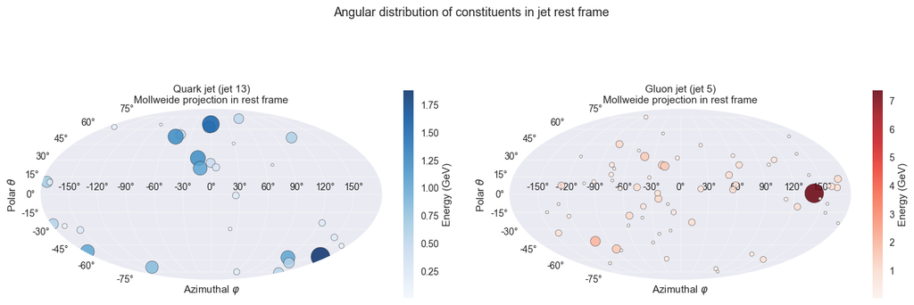

```python
## Mollweide rest-frame projection (radiation pattern around the jet axis in its rest frame)
## ref: https://matplotlib.org/stable/gallery/subplots_axes_and_figures/geo_demo.html

def p4_to_spherical(p4):
    """Return (theta, phi, E) from (E, px, py, pz) array."""
    E  = p4[:, 0]
    px, py, pz = p4[:, 1], p4[:, 2], p4[:, 3]
    p_mag = np.sqrt(px**2 + py**2 + pz**2)
    theta = np.arccos(np.clip(pz / (p_mag + 1e-30), -1, 1))  # polar angle [0, π]
    phi   = np.arctan2(py, px)                                # azimuthal [-π, π]
    return theta, phi, E

q_idx = quark_indices[5]
g_idx = gluon_indices[5]

fig, axes = plt.subplots(1, 2, subplot_kw={'projection': 'mollweide'},
                         figsize=(14, 5))

for ax, idx, label, cmap in zip(
    axes,
    [q_idx, g_idx],
    ['Quark jet', 'Gluon jet'],
    ['Blues', 'Reds']
):
    p4_rest, _, _ = boost_to_rest_frame(X[idx])
    theta, phi, E = p4_to_spherical(p4_rest)
    lat = np.pi / 2 - theta

    E_norm = E / E.max()
    sizes  = np.clip(E_norm * 400, 10, 400)

    sc = ax.scatter(phi, lat, s=sizes, c=E, cmap=cmap,
                    alpha=0.85, edgecolors='k', linewidths=0.3)
    plt.colorbar(sc, ax=ax, label='Energy (GeV)', shrink=0.7)
    ax.set_title(f'{label} (jet {idx})\nMollweide projection in rest frame',
                 fontsize=11)
    ax.grid(True, alpha=0.3)
    ax.set_xlabel(r'Azimuthal $\varphi$')
    ax.set_ylabel(r'Polar $\theta$')

fig.suptitle('Angular distribution of constituents in jet rest frame', fontsize=13, y=1.02)
fig.tight_layout()
plt.show()
```

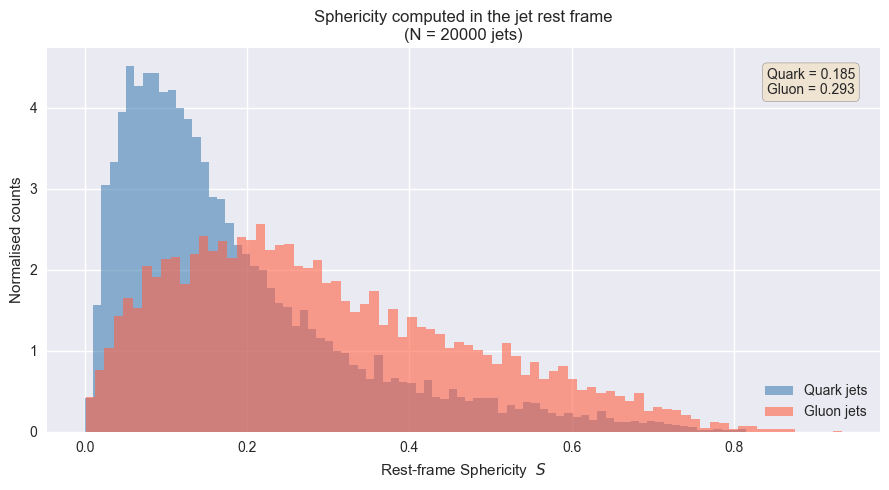

```python
## Rest-frame sphericity tensor & isotropy observable

def sphericity(jet):
    """Compute the rest-frame sphericity S ∈ [0, 1]."""
    p4_rest, _, _ = boost_to_rest_frame(jet)
    p3 = p4_rest[:, 1:]               # (N, 3)
    p2 = np.sum(p3**2, axis=1)
    norm = p2.sum()
    if norm < 1e-20:
        return np.nan
    S_tensor = (p3.T @ p3) / norm
    eigvals = np.linalg.eigvalsh(S_tensor)
    lam2, lam3 = eigvals[1], eigvals[2]
    lam1, lam2_val = eigvals[0], eigvals[1]
    S = 1.5 * (lam1 + lam2_val)
    return float(S)

N_sph = 20_000 ## full set took too long so a subset
sph_q, sph_g = [], []

for i in range(N_sph):
    s = sphericity(X[i])
    if not np.isnan(s):
        (sph_q if y[i] == 1 else sph_g).append(s)

sph_q = np.array(sph_q)
sph_g = np.array(sph_g)

fig, ax = plt.subplots(figsize=(9, 5))
ax.hist(sph_q, bins=80, density=True, alpha=0.6, color=QUARK_COLOR, label='Quark jets')
ax.hist(sph_g, bins=80, density=True, alpha=0.6, color=GLUON_COLOR, label='Gluon jets')
ax.set_xlabel('Rest-frame Sphericity  $S$')
ax.set_ylabel('Normalised counts')
ax.set_title(r'Sphericity computed in the jet rest frame'
             f'\n(N = {N_sph} jets)')
ax.legend()
ax.text(0.97, 0.95,
        f"Quark = {sph_q.mean():.3f}\nGluon = {sph_g.mean():.3f}",
        transform=ax.transAxes, ha='right', va='top',
        bbox=dict(boxstyle='round', facecolor='wheat', alpha=0.5))
fig.tight_layout()
plt.show()
```

**Rest-Frame Constituent Scatter Plots**

Constituents are displayed in the $(p_x', p_y')$ plane of the jet rest frame, with marker size proportional to rest-frame energy. A Mollweide projection of the full spherical distribution $(\theta, \varphi)$ is shown for additional angular coverage.

**Observations:**

These differences are consistent with the lab-frame observables: gluon jets have larger mean width and lower $p_T^D$ (more uniform energy sharing), while quark jets are harder and more collimated. The rest frame makes this structure directly visible in 3D momentum space, without the kinematic smearing from the lab-frame longitudinal boost.

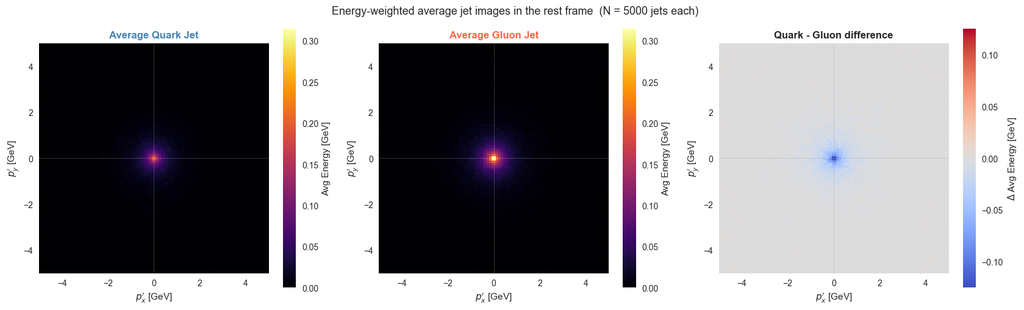

```python
## Average jet image in the rest frame

rng = np.random.default_rng(42)
q_jets_idx = np.where(y == 1)[0]
g_jets_idx  = np.where(y == 0)[0]

n_img    = 5000
nbins_img = 100
img_range = 5  # GeV

q_sample = rng.choice(q_jets_idx, n_img, replace=False)
g_sample = rng.choice(g_jets_idx,  n_img, replace=False)

def make_avg_image(indices, nbins, rng_val):
    """Average 2D histogram of (px', py') energy-weighted over many jets."""
    edges = np.linspace(-rng_val, rng_val, nbins + 1)
    total = np.zeros((nbins, nbins))
    for idx in indices:
        p4_rest, _, _ = boost_to_rest_frame(X[idx])   # (N,4): [E, px, py, pz]
        h, _, _ = np.histogram2d(
            p4_rest[:, 1], p4_rest[:, 2],  # px', py'
            bins=edges,
            weights=p4_rest[:, 0]  # weight by E'
        )
        total += h
    return total / len(indices), edges

img_q, edges_img = make_avg_image(q_sample, nbins_img, img_range)
img_g, _         = make_avg_image(g_sample, nbins_img, img_range)

fig, axes = plt.subplots(1, 3, figsize=(17, 5))
vmax_img = max(img_q.max(), img_g.max())
vmin_img = 0.0

extent = [-img_range, img_range, -img_range, img_range]

for ax, img, ttl, color in zip(
    axes[:2],
    [img_q, img_g],
    ['Average Quark Jet', 'Average Gluon Jet'],
    [QUARK_COLOR, GLUON_COLOR]
):
    im = ax.imshow(
        img.T, origin='lower', extent=extent,
        cmap='inferno', aspect='equal',
        vmin=vmin_img, vmax=vmax_img
    )
    ax.set_xlabel(r"$p_x'$ [GeV]")
    ax.set_ylabel(r"$p_y'$ [GeV]")
    ax.set_title(ttl, color=color, fontweight='bold')
    ax.axhline(0, color='white', lw=0.4, ls='--', alpha=0.5)
    ax.axvline(0, color='white', lw=0.4, ls='--', alpha=0.5)
    ax.grid(False)
    plt.colorbar(im, ax=ax, label='Avg Energy [GeV]')

diff = img_q - img_g
vext = np.abs(diff).max()
im_d = axes[2].imshow(
    diff.T, origin='lower', extent=extent,
    cmap='coolwarm', aspect='equal',
    vmin=-vext, vmax=vext
)
axes[2].set_xlabel(r"$p_x'$ [GeV]")
axes[2].set_ylabel(r"$p_y'$ [GeV]")
axes[2].set_title('Quark - Gluon difference', fontweight='bold')
axes[2].axhline(0, color='grey', lw=0.4, ls='--', alpha=0.6)
axes[2].axvline(0, color='grey', lw=0.4, ls='--', alpha=0.6)
axes[2].grid(False)
plt.colorbar(im_d, ax=axes[2], label=r'$\Delta$ Avg Energy [GeV]')

fig.suptitle(
    f'Energy-weighted average jet images in the rest frame  (N = {n_img} jets each)',
    fontsize=13
)
fig.tight_layout()
plt.show()
```

## Task D: Quark vs. Gluon Jet Classification

Seven features are computed per jet in the rest frame:

| Feature | Description | Motivation |
| --- | --- | --- |
| $N$ (multiplicity) | Number of real constituents | Lorentz-invariant; the strongest single discriminant. |
| $m_J$ (jet mass) | Invariant mass from summed four-momenta | Lorentz-invariant; gluon jets seem to have a higher mass. |
| $\text{Width}_{\text{RF}}$ | $p_T$-weighted $\Delta R$ from jet axis, computed in rest frame | Captures angular spread; redundant with lab width but evaluated in the frame where the jet axis is unambiguous. |
| $p_T^D$ (rest frame) | $\sqrt{\sum p_i^2}/\sum p_i$ using $\lvert\vec{p}_i'\rvert$ in rest frame | Measures hardness of the radiation pattern; quarks score higher. |
| Sphericity $S$ | $\frac{3}{2}(\lambda_2 + \lambda_3)$ from the normalised 3D momentum tensor | Captures isotropy of radiation in 3D - only accessible in the rest frame. $S \approx 1$ for isotropic (gluon-like), $S \approx 0$ for pencil-like (quark-like). |
| Aplanarity $A$ | $\frac{3}{2}\lambda_3$ from the same tensor | Measures out-of-plane momentum; complements sphericity with sensitivity to a different eigenvalue. |
| $z_{\text{max}}$ | Leading constituent energy fraction $E_{\text{max}}/\sum E_i$ | Measures how dominant the leading fragment is; quarks tend to have a dominant core. |

Multiplicity, jet mass, $p_T^D$, and $z_{\text{max}}$ are Lorentz-invariant or frame-insensitive by construction. Sphericity and aplanarity are strictly rest-frame quantities - they require 3D momentum information, which is only physically meaningful in the frame where the jet is at rest. These two features encode the full 3D shape of the radiation pattern and are the primary motivation for working in the rest frame.

```python
## Feature Engineering in the Rest Frame - using features from task B nd sphericity/aplanarity from task C computed in the rest framee.

from tqdm import tqdm

def compute_rest_frame_features(jet):
    """
    Returns a dict of rest-frame observables for a single jet.
    Keys: n, mass_rf, width_rf, ptd_rf, sphericity, aplanarity, z_max
    """
    # Boost to rest frame
    p4_rest, _, _ = boost_to_rest_frame(jet)   # (N, 4): [E, px, py, pz]
    E   = p4_rest[:, 0]
    p3  = p4_rest[:, 1:]                        # (N, 3)
    p_mag = np.linalg.norm(p3, axis=1)

    N = len(E)

    # Jet mass
    p_jet = p4_rest.sum(axis=0)
    m2 = p_jet[0]**2 - np.dot(p_jet[1:], p_jet[1:])
    mass = np.sqrt(max(m2, 0.0))

    # Rest-frame pTD
    sum_p   = p_mag.sum()
    sum_p2  = np.dot(p_mag, p_mag)
    ptd_rf  = np.sqrt(sum_p2) / sum_p if sum_p > 0 else 0.0

    # Rest-frame jet width
    px, py, pz = p3[:, 0], p3[:, 1], p3[:, 2]
    pT_rf  = np.sqrt(px**2 + py**2)
    pT_sum = pT_rf.sum()
    phi_rf = np.arctan2(py, px)
    eta_rf = np.arcsinh(pz / (pT_rf + 1e-12))  # rapidity substi in rest frame

    # jet axis eta/phi from pT-weighted centroid
    phi_J_rf = np.arctan2(np.dot(pT_rf, np.sin(phi_rf)),
                           np.dot(pT_rf, np.cos(phi_rf)))
    eta_J_rf = np.dot(pT_rf, eta_rf) / (pT_sum + 1e-12)
    dphi_rf  = (phi_rf - phi_J_rf + np.pi) % (2 * np.pi) - np.pi
    deta_rf  = eta_rf - eta_J_rf
    dR_rf    = np.sqrt(deta_rf**2 + dphi_rf**2)
    width_rf = np.dot(pT_rf, dR_rf) / (pT_sum + 1e-12)

    # Sphericity & Aplanarity from 3D momentum
    if sum_p2 > 0:
        T = (p3.T @ p3) / sum_p2     # (3, 3)
        eigvals = np.linalg.eigvalsh(T)
        lam1, lam2, lam3 = eigvals[::-1]
        sphericity  = 1.5 * (lam2 + lam3)
        aplanarity  = 1.5 * lam3
    else:
        sphericity = aplanarity = 0.0

    # Leading energy fraction
    z_max = E.max() / (E.sum() + 1e-12)

    return {
        'n':          N,
        'mass':       mass,
        'width_rf':   width_rf,
        'ptd_rf':     ptd_rf,
        'sphericity': sphericity,
        'aplanarity': aplanarity,
        'z_max':      z_max,
    }

rest_features_list = [compute_rest_frame_features(X[i]) for i in tqdm(range(len(X)))]

feat_keys_rf = ['n', 'mass', 'width_rf', 'ptd_rf', 'sphericity', 'aplanarity', 'z_max']
feat_labels_rf = ['Multiplicity (N)', 'Jet mass [GeV]', 'Width (RF)',
                  'pTD (RF)', 'Sphericity', 'Aplanarity', 'z_max']

F_rf = np.array([[d[k] for k in feat_keys_rf] for d in rest_features_list])
print(f"\nMatrix shape: {F_rf.shape}")
print(f"Features: {feat_keys_rf}")

nan_mask = np.isnan(F_rf)       ## checking nans --> median substi
n_nans_total = int(np.count_nonzero(nan_mask))
nan_per_col = np.sum(nan_mask, axis=0).astype(int)
print(f"\nTotal NaNs in F_rf: {n_nans_total}")
for k, c in zip(feat_keys_rf, nan_per_col):
    print(f" - {k}: {int(c)}")

if n_nans_total > 0:
    col_medians = np.nanmedian(F_rf, axis=0)
    col_medians = np.where(np.isnan(col_medians), 0.0, col_medians)
    inds = np.where(np.isnan(F_rf))
    F_rf[inds] = np.take(col_medians, inds[1])
    print(f"Replaced {n_nans_total} NaNs using column medians.")
    print(f"Remaining NaNs after fill: {int(np.count_nonzero(np.isnan(F_rf)))}")
else:
    print("No NaNs")
```

```
Matrix shape: (500000, 7)
Features: ['n', 'mass', 'width_rf', 'ptd_rf', 'sphericity', 'aplanarity', 'z_max']

Total NaNs in F_rf: 12
 - n: 0
 - mass: 4
 - width_rf: 4
 - ptd_rf: 0
 - sphericity: 0
 - aplanarity: 0
 - z_max: 4
Replaced 12 NaNs using column medians.
Remaining NaNs after fill: 0
```

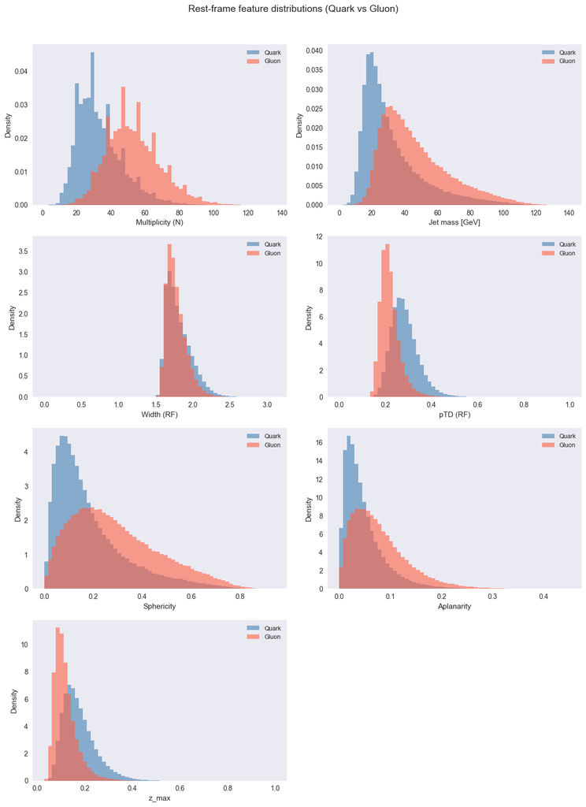

```python
# Rest-frame features

feat_names_rf = feat_labels_rf
F = F_rf  # rest-frame feature matrix
n_feat = F.shape[1]

rows = math.ceil(n_feat / 2)
fig, axes = plt.subplots(rows, 2, figsize=(12, 4 * rows))
axes = axes.ravel()

for i in range(n_feat):
    ax = axes[i]
    data_q = F[y == 1, i]
    data_g = F[y == 0, i]

    bins = np.histogram_bin_edges(np.concatenate([data_q, data_g]), bins=60)    ## shared bins for quark/gluon comparison
    ax.hist(data_q, bins=bins, density=True, alpha=0.6, color=QUARK_COLOR, label='Quark')
    ax.hist(data_g, bins=bins, density=True, alpha=0.6, color=GLUON_COLOR, label='Gluon')
    ax.set_xlabel(feat_names_rf[i])
    ax.set_ylabel('Density')
    ax.legend(fontsize=9)
    ax.grid(False)

for j in range(n_feat, len(axes)):
    axes[j].axis('off')

fig.suptitle('Rest-frame feature distributions (Quark vs Gluon)', fontsize=14, y=1.02)
fig.tight_layout()
plt.show()
```

```python
## Lab-frame feature matrix

def leading_pt_fraction(jet):
    real = remove_padding(jet)
    pt = real[:, 0]
    return pt.max() / (pt.sum() + 1e-12)

z_max_lab = np.array([leading_pt_fraction(X[i]) for i in tqdm(range(len(X)))])

feat_labels_lab = ['Multiplicity (N)', 'Jet mass [GeV]', 'Width (lab)', 'pTD (lab)', 'z_max (lab)']

F_lab = np.column_stack([multiplicities, masses, widths, ptd, z_max_lab])
print(f"Lab-frame feature matrix shape:  {F_lab.shape}")
print(f"Rest-frame feature matrix shape: {F_rf.shape}")
```

```
Lab-frame feature matrix shape:  (500000, 5)
Rest-frame feature matrix shape: (500000, 7)
```

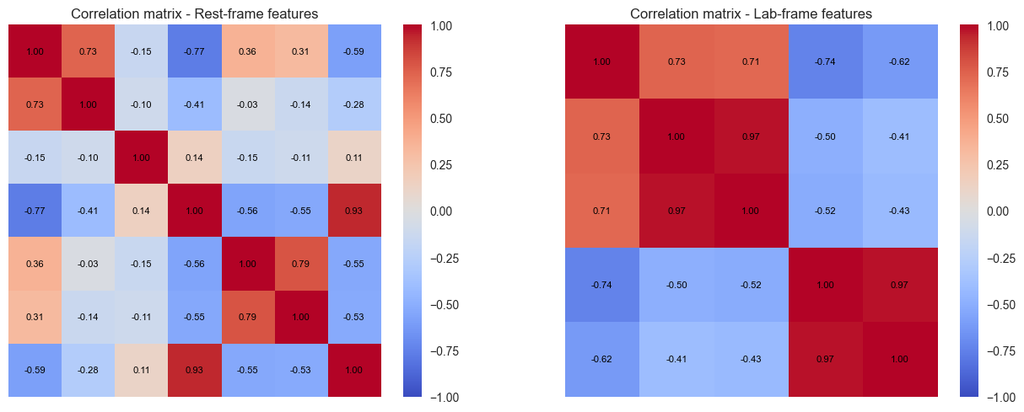

```python
# Correlation matrix

fig, axes = plt.subplots(1, 2, figsize=(14, 5))

# Rest-frame correlation
corr_rf = np.corrcoef(F_rf.T)
im0 = axes[0].imshow(corr_rf, cmap='coolwarm', vmin=-1, vmax=1)
axes[0].set_xticks(range(len(feat_names_rf)))
axes[0].set_yticks(range(len(feat_names_rf)))
axes[0].set_xticklabels(feat_names_rf, rotation=45, ha='right')
axes[0].set_yticklabels(feat_names_rf)
axes[0].set_title('Correlation matrix - Rest-frame features')
for i in range(len(feat_names_rf)):
    for j in range(len(feat_names_rf)):
        axes[0].text(j, i, f"{corr_rf[i, j]:.2f}", ha='center', va='center', fontsize=8, color='black')

plt.colorbar(im0, ax=axes[0], fraction=0.046, pad=0.04)
axes[0].axis('off')


feat_names_lab = feat_labels_lab
corr_lab = np.corrcoef(F_lab.T)
im1 = axes[1].imshow(corr_lab, cmap='coolwarm', vmin=-1, vmax=1)
axes[1].set_xticks(range(len(feat_names_lab)))
axes[1].set_yticks(range(len(feat_names_lab)))
axes[1].set_xticklabels(feat_names_lab, rotation=45, ha='right')
axes[1].set_yticklabels(feat_names_lab)
axes[1].set_title('Correlation matrix - Lab-frame features')
for i in range(len(feat_names_lab)):
    for j in range(len(feat_names_lab)):
        axes[1].text(j, i, f"{corr_lab[i, j]:.2f}", ha='center', va='center', fontsize=8, color='black')

plt.colorbar(im1, ax=axes[1], fraction=0.046, pad=0.04)
axes[1].axis('off')

fig.tight_layout()
plt.show()
```

```python
## Train - Test split & feature scaling

# Rest frame
X_tr_rf, X_te_rf, y_tr, y_te = train_test_split(
    F_rf, y, test_size=TEST_SIZE, random_state=RANDOM_SEED, stratify=y
)

# Lab frame
X_tr_lab, X_te_lab, _, _ = train_test_split(
    F_lab, y, test_size=TEST_SIZE, random_state=RANDOM_SEED, stratify=y
)

# Standard-scale
scaler_rf  = StandardScaler().fit(X_tr_rf)
scaler_lab = StandardScaler().fit(X_tr_lab)

Xtr_rf_sc  = scaler_rf.transform(X_tr_rf)
Xte_rf_sc  = scaler_rf.transform(X_te_rf)
Xtr_lab_sc = scaler_lab.transform(X_tr_lab)
Xte_lab_sc = scaler_lab.transform(X_te_lab)

print(f"Train size: {len(y_tr):,}\nTest size: {len(y_te):,}")
```

```
Train size: 400,000
Test size: 100,000
```

```python
## Train classifiers on REST-FRAME features

classifiers_rf = {
    'Gradient Boosting': GradientBoostingClassifier(
        n_estimators=256, max_depth=4, learning_rate=0.1,
        subsample=0.8, min_samples_leaf=50, random_state=RANDOM_SEED
    ),
    'Random Forest': RandomForestClassifier(
        n_estimators=512, max_depth=6, min_samples_leaf=50,
        n_jobs=-1, random_state=RANDOM_SEED
    ),
    'Logistic Regression': LogisticRegression(
        C=1.0, max_iter=512, solver='lbfgs', random_state=RANDOM_SEED
    ),
}

scores_rf  = {}
auc_rf     = {}
metrics_rf = {}

for name, clf in classifiers_rf.items():
    t0 = time.time()
    Xtr = Xtr_rf_sc if 'Logistic' in name else X_tr_rf
    Xte = Xte_rf_sc if 'Logistic' in name else X_te_rf
    clf.fit(Xtr, y_tr)
    prob  = clf.predict_proba(Xte)[:, 1]
    y_hat = clf.predict(Xte)

    auc   = roc_auc_score(y_te, prob)
    acc   = accuracy_score(y_te, y_hat)
    f1    = f1_score(y_te, y_hat)
    prec  = precision_score(y_te, y_hat)
    rec   = recall_score(y_te, y_hat)

    scores_rf[name]  = prob
    auc_rf[name]     = auc
    metrics_rf[name] = dict(AUC=auc, Accuracy=acc, F1=f1,
                             Precision=prec, Recall=rec)

    print(f"  {name:<25s}  AUC={auc:.4f}  Acc={acc:.4f}  F1={f1:.4f}  Prec={prec:.4f}  Rec={rec:.4f}   ({time.time()-t0:.1f}s)")
```

```
  Gradient Boosting          AUC=0.8632  Acc=0.7831  F1=0.7771  Prec=0.7992  Rec=0.7562   (398.6s)
  Random Forest              AUC=0.8592  Acc=0.7805  F1=0.7742  Prec=0.7970  Rec=0.7527   (71.7s)
  Logistic Regression        AUC=0.8503  Acc=0.7755  F1=0.7759  Prec=0.7746  Rec=0.7771   (0.5s)
```

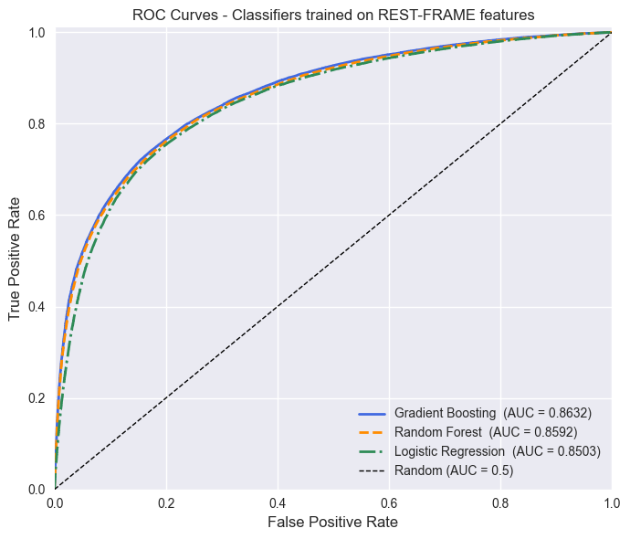

```python
## ROC curves - REST-FRAME classifiers

fig, ax = plt.subplots(figsize=(7, 6))
linestyles = ['-', '--', '-.']
colors_clf  = ['royalblue', 'darkorange', 'seagreen']

for (name, prob), ls, c in zip(scores_rf.items(), linestyles, colors_clf):
    fpr, tpr, _ = roc_curve(y_te, prob)
    ax.plot(fpr, tpr, ls=ls, color=c, lw=2,
            label=f'{name}  (AUC = {auc_rf[name]:.4f})')

ax.plot([0, 1], [0, 1], 'k--', lw=1, label='Random (AUC = 0.5)')
ax.set_xlabel('False Positive Rate', fontsize=12)
ax.set_ylabel('True Positive Rate', fontsize=12)
ax.set_title('ROC Curves - Classifiers trained on REST-FRAME features', fontsize=12)
ax.legend(fontsize=10)
ax.set_xlim(0, 1); ax.set_ylim(0, 1.01)
fig.tight_layout()
plt.show()
```

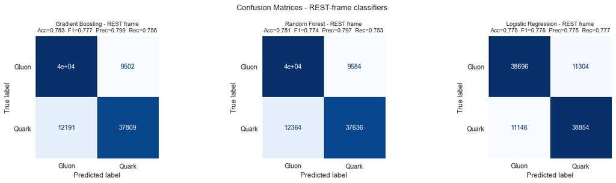

```python
## Confusion Matrices

fig, axes = plt.subplots(1, 3, figsize=(15, 4))

for ax, name in zip(axes, classifiers_rf):
    y_hat = (scores_rf[name] >= 0.5).astype(int)
    cm    = confusion_matrix(y_te, y_hat)
    disp  = ConfusionMatrixDisplay(confusion_matrix=cm,
                                   display_labels=['Gluon', 'Quark'])
    disp.plot(ax=ax, colorbar=False, cmap='Blues')
    m = metrics_rf[name]
    ax.set_title(
        f'{name} - REST frame\n'
        f'Acc={m["Accuracy"]:.3f}  F1={m["F1"]:.3f}  '
        f'Prec={m["Precision"]:.3f}  Rec={m["Recall"]:.3f}',
        fontsize=9
    )
    ax.grid(False)

fig.suptitle('Confusion Matrices - REST-frame classifiers', fontsize=12)
fig.tight_layout()
plt.show()
```

```
Per-feature AUC:

Multiplicity (N)           AUC = 0.8399
pTD (RF)                   AUC = 0.8295
z_max                      AUC = 0.7759
Jet mass [GeV]             AUC = 0.7390
Sphericity                 AUC = 0.6942
Aplanarity                 AUC = 0.6938
Width (RF)                 AUC = 0.5445


Most discriminating single feature: 'Multiplicity (N)'  (AUC = 0.8399)
```

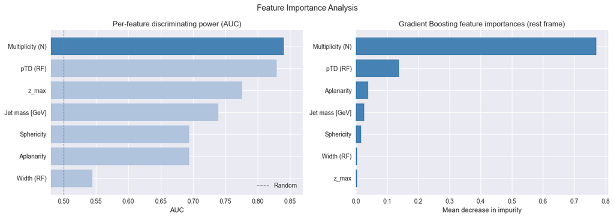

```python
## Feature Importance

# Per-feature AUC ranking (model agnostic)
per_feat_auc = {}
for k, lbl in zip(feat_keys_rf, feat_labels_rf):
    col = F_rf[len(X_tr_rf):]        # test portion
    feat_idx = feat_keys_rf.index(k)
    auc_1d = roc_auc_score(y_te, X_te_rf[:, feat_idx])
    per_feat_auc[lbl] = max(auc_1d, 1 - auc_1d)

sorted_feats = sorted(per_feat_auc.items(), key=lambda x: x[1], reverse=True)
feat_names_sorted, feat_aucs_sorted = zip(*sorted_feats)

print("Per-feature AUC:\n")
for fn, fa in sorted_feats:
    print(f"{fn:<25s}  AUC = {fa:.4f}")

print(f"\n\nMost discriminating single feature: '{feat_names_sorted[0]}'  (AUC = {feat_aucs_sorted[0]:.4f})")

# GBT built-in importances (impurity-based)
gbt_clf = classifiers_rf['Gradient Boosting']
importances = gbt_clf.feature_importances_

fig, axes = plt.subplots(1, 2, figsize=(14, 5))

# Left - per-feature AUC
colors_bar = [QUARK_COLOR if i == 0 else 'lightsteelblue' for i in range(len(feat_names_sorted))]
axes[0].barh(feat_names_sorted[::-1], feat_aucs_sorted[::-1], color=colors_bar[::-1])
axes[0].axvline(0.5, color='grey', ls='--', lw=1, label='Random')
axes[0].set_xlabel('AUC')
axes[0].set_title('Per-feature discriminating power (AUC)')
axes[0].set_xlim(0.48, max(feat_aucs_sorted) + 0.03)
axes[0].legend()

# Right- GBT feature importances
imp_order = np.argsort(importances)
axes[1].barh(
    [feat_labels_rf[i] for i in imp_order],
    importances[imp_order],
    color='steelblue'
)
axes[1].set_xlabel('Mean decrease in impurity')
axes[1].set_title('Gradient Boosting feature importances (rest frame)')

fig.suptitle('Feature Importance Analysis', fontsize=13)
fig.tight_layout()
plt.show()
```

```python
## Train classifiers on LAB-FRAME features

classifiers_lab = {
    'Gradient Boosting': GradientBoostingClassifier(
        n_estimators=300, max_depth=4, learning_rate=0.1,
        subsample=0.8, min_samples_leaf=50, random_state=RANDOM_SEED
    ),
    'Random Forest': RandomForestClassifier(
        n_estimators=512, max_depth=5, min_samples_leaf=50,
        n_jobs=-1, random_state=RANDOM_SEED
    ),
    'Logistic Regression': LogisticRegression(
        C=1.0, max_iter=512, solver='lbfgs', random_state=RANDOM_SEED
    ),
}

scores_lab  = {}
auc_lab     = {}
metrics_lab = {}

for name, clf in classifiers_lab.items():
    t0 = time.time()
    Xtr = Xtr_lab_sc if 'Logistic' in name else X_tr_lab
    Xte = Xte_lab_sc if 'Logistic' in name else X_te_lab
    clf.fit(Xtr, y_tr)
    prob  = clf.predict_proba(Xte)[:, 1]
    y_hat = clf.predict(Xte)

    auc  = roc_auc_score(y_te, prob)
    acc  = accuracy_score(y_te, y_hat)
    f1   = f1_score(y_te, y_hat)
    prec = precision_score(y_te, y_hat)
    rec  = recall_score(y_te, y_hat)

    scores_lab[name]  = prob
    auc_lab[name]     = auc
    metrics_lab[name] = dict(AUC=auc, Accuracy=acc, F1=f1,
                              Precision=prec, Recall=rec)

    print(f"  {name:<25s}  AUC={auc:.4f}  Acc={acc:.4f}  F1={f1:.4f}  Prec={prec:.4f}  Rec={rec:.4f}   ({time.time()-t0:.1f}s)")
```

```
  Gradient Boosting          AUC=0.8651  Acc=0.7853  F1=0.7823  Prec=0.7936  Rec=0.7713   (332.3s)
  Random Forest              AUC=0.8546  Acc=0.7763  F1=0.7671  Prec=0.8001  Rec=0.7366   (62.4s)
  Logistic Regression        AUC=0.8518  Acc=0.7794  F1=0.7791  Prec=0.7803  Rec=0.7778   (0.5s)
```

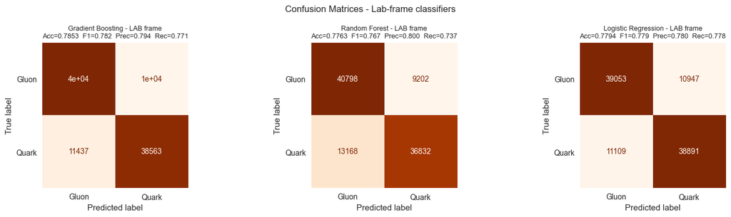

```python
## Confusion Matrices - ALL LAB-FRAME classifiers
fig, axes = plt.subplots(1, 3, figsize=(15, 4))

for ax, name in zip(axes, classifiers_lab):
    y_hat = (scores_lab[name] >= 0.5).astype(int)
    cm    = confusion_matrix(y_te, y_hat)
    disp  = ConfusionMatrixDisplay(confusion_matrix=cm,
                                   display_labels=['Gluon', 'Quark'])
    disp.plot(ax=ax, colorbar=False, cmap='Oranges')
    m = metrics_lab[name]
    ax.set_title(
        f'{name} - LAB frame\n'
        f'Acc={m["Accuracy"]:.4f}  F1={m["F1"]:.3f}  '
        f'Prec={m["Precision"]:.3f}  Rec={m["Recall"]:.3f}',
        fontsize=9
    )
    ax.grid(False)

fig.suptitle('Confusion Matrices - Lab-frame classifiers', fontsize=12)
fig.tight_layout()
plt.show()
```

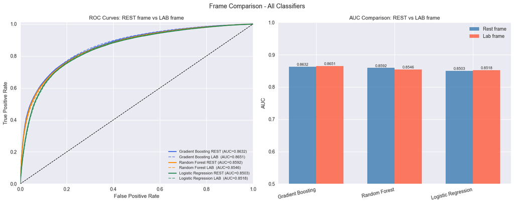

```
═════════════════════════════════════════════════════════════════════════════════════════════
  FULL METRICS SUMMARY - REST frame vs LAB frame
═════════════════════════════════════════════════════════════════════════════════════════════
Classifier                 Frame          AUC    Accuracy          F1   Precision      Recall
─────────────────────────────────────────────────────────────────────────────────────────────
Gradient Boosting          REST        0.8632      0.7831      0.7771      0.7992      0.7562
Gradient Boosting          LAB         0.8651      0.7853      0.7823      0.7936      0.7713
─────────────────────────────────────────────────────────────────────────────────────────────
Random Forest              REST        0.8592      0.7805      0.7742      0.7970      0.7527
Random Forest              LAB         0.8546      0.7763      0.7671      0.8001      0.7366
─────────────────────────────────────────────────────────────────────────────────────────────
Logistic Regression        REST        0.8503      0.7755      0.7759      0.7746      0.7771
Logistic Regression        LAB         0.8518      0.7794      0.7791      0.7803      0.7778
─────────────────────────────────────────────────────────────────────────────────────────────
```

```python
## Summary

fig, axes = plt.subplots(1, 2, figsize=(15, 6))

frame_colors = {
    'Gradient Boosting':   'royalblue',
    'Random Forest':       'darkorange',
    'Logistic Regression': 'seagreen',
}

ax = axes[0]
for name in classifiers_rf:
    fpr_r, tpr_r, _ = roc_curve(y_te, scores_rf[name])
    fpr_l, tpr_l, _ = roc_curve(y_te, scores_lab[name])
    c = frame_colors[name]
    ax.plot(fpr_r, tpr_r, '-',  color=c, lw=2,
            label=f'{name} REST (AUC={auc_rf[name]:.4f})')
    ax.plot(fpr_l, tpr_l, '--', color=c, lw=1.5, alpha=0.7,
            label=f'{name} LAB  (AUC={auc_lab[name]:.4f})')

ax.plot([0, 1], [0, 1], 'k--', lw=1)
ax.set_xlabel('False Positive Rate', fontsize=11)
ax.set_ylabel('True Positive Rate', fontsize=11)
ax.set_title('ROC Curves: REST frame vs LAB frame', fontsize=11)
ax.legend(fontsize=8, loc='lower right')
ax.set_xlim(0, 1); ax.set_ylim(0, 1.01)

ax2 = axes[1]
clf_names = list(classifiers_rf.keys())
x = np.arange(len(clf_names))
w = 0.35

bars_rf  = ax2.bar(x - w/2, [auc_rf[n]  for n in clf_names], w,
                   label='Rest frame', color='steelblue', alpha=0.85)
bars_lab = ax2.bar(x + w/2, [auc_lab[n] for n in clf_names], w,
                   label='Lab frame',  color='tomato',    alpha=0.85)

for bar in bars_rf + bars_lab:
    h = bar.get_height()
    ax2.text(bar.get_x() + bar.get_width()/2, h + 0.001, f'{h:.4f}',
             ha='center', va='bottom', fontsize=8)

ax2.set_xticks(x); ax2.set_xticklabels(clf_names, rotation=12, ha='right')
ax2.set_ylabel('AUC'); ax2.set_ylim(0.5, 1.0)
ax2.set_title('AUC Comparison: REST vs LAB frame', fontsize=11)
ax2.legend()
fig.suptitle('Frame Comparison - All Classifiers', fontsize=13)
fig.tight_layout()
plt.show()

## Table
metric_keys  = ['AUC', 'Accuracy', 'F1', 'Precision', 'Recall']

col_width = 10
name_width = 25
header_parts = [f"{'Classifier':<{name_width}}", f"{'Frame':<6}"]
header_parts += [f"{m:>{col_width}}" for m in metric_keys]
header = "  ".join(header_parts)
sep    = "─" * len(header)

print("\n" + "═" * len(header))
print("  FULL METRICS SUMMARY - REST frame vs LAB frame")
print("═" * len(header))
print(header)
print(sep)

for name in clf_names:
    for frame_label, mdict in [('REST', metrics_rf[name]), ('LAB', metrics_lab[name])]:
        row = [f"{name:<{name_width}}", f"{frame_label:<6}"]
        row += [f"{mdict[m]:>{col_width}.4f}" for m in metric_keys]
        print("  ".join(row))
    print(sep)
```

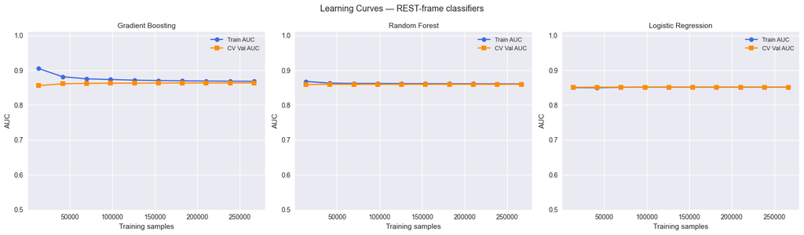

```python
## Learning curves - to check for overfitting

from sklearn.model_selection import learning_curve

TRAIN_SIZES = np.linspace(0.05, 1.0, 10)

fig, axes = plt.subplots(1, 3, figsize=(17, 5), sharey=False)

lc_clfs = {
    'Gradient Boosting':   (classifiers_rf['Gradient Boosting'],   X_tr_rf,  y_tr),
    'Random Forest':        (classifiers_rf['Random Forest'],        X_tr_rf,  y_tr),
    'Logistic Regression':  (classifiers_rf['Logistic Regression'], Xtr_rf_sc, y_tr),
}

for ax, (name, (clf, Xtr, ytr)) in zip(axes, lc_clfs.items()):
    train_sizes_abs, train_scores, val_scores = learning_curve(
        clf, Xtr, ytr,
        train_sizes=TRAIN_SIZES,
        cv=3,
        scoring='roc_auc',
        n_jobs=-1,
        random_state=RANDOM_SEED,
    )
    tr_mean  = train_scores.mean(axis=1)
    tr_std   = train_scores.std(axis=1)
    val_mean = val_scores.mean(axis=1)
    val_std  = val_scores.std(axis=1)

    ax.fill_between(train_sizes_abs, tr_mean - tr_std, tr_mean + tr_std,
                    alpha=0.15, color='royalblue')
    ax.fill_between(train_sizes_abs, val_mean - val_std, val_mean + val_std,
                    alpha=0.15, color='darkorange')
    ax.plot(train_sizes_abs, tr_mean,  'o-', color='royalblue',   label='Train AUC')
    ax.plot(train_sizes_abs, val_mean, 's-', color='darkorange',  label='CV Val AUC')

    ax.set_xlabel('Training samples', fontsize=11)
    ax.set_ylabel('AUC', fontsize=11)
    ax.set_title(name, fontsize=11)
    ax.legend(fontsize=9)
    ax.set_ylim(0.5, 1.01)

fig.suptitle('Learning Curves - REST-frame classifiers', fontsize=13)
fig.tight_layout()
plt.show()
```

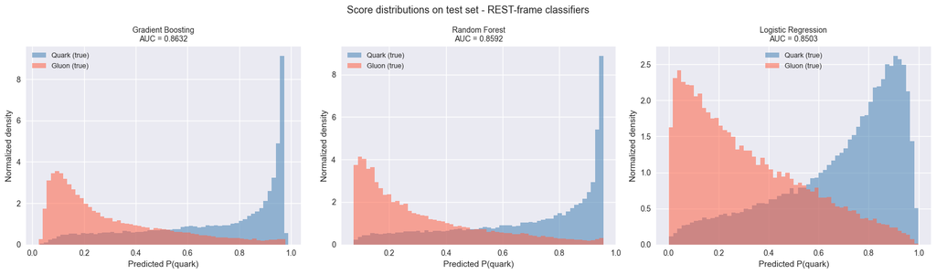

```python
## Classifier score distribution

fig, axes = plt.subplots(1, 3, figsize=(17, 5))

for ax, name in zip(axes, classifiers_rf):
    prob = scores_rf[name]
    ax.hist(prob[y_te == 1], bins=60, density=True, alpha=0.55,
            color=QUARK_COLOR, label='Quark (true)')
    ax.hist(prob[y_te == 0], bins=60, density=True, alpha=0.55,
            color=GLUON_COLOR, label='Gluon (true)')
    ax.set_xlabel('Predicted P(quark)', fontsize=11)
    ax.set_ylabel('Normalized density', fontsize=11)
    ax.set_title(f'{name}\nAUC = {auc_rf[name]:.4f}', fontsize=10)
    ax.legend(fontsize=9)

fig.suptitle('Score distributions on test set - REST-frame classifiers', fontsize=13)
fig.tight_layout()
plt.show()
```

```
Converged after (18.2s)

MLP (REST)   AUC=0.8637  Acc=0.7834  F1=0.7770  Prec=0.8008  Rec=0.7546
```

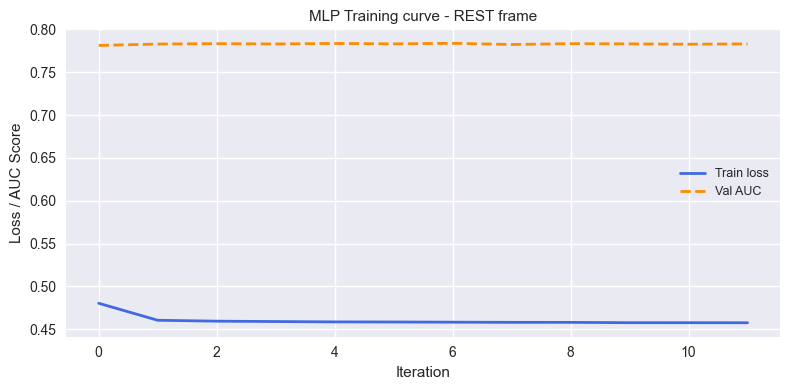

```python
## Neural Network - REST-FRAME features

from sklearn.neural_network import MLPClassifier

mlp_rf = MLPClassifier(
    hidden_layer_sizes=(64, 32, 16),
    activation='relu',
    solver='adam',
    alpha=1e-4,
    batch_size=1024,
    learning_rate='adaptive',
    learning_rate_init=1e-3,
    max_iter=15,
    early_stopping=True,
    validation_fraction=0.10,
    n_iter_no_change=4,
    random_state=RANDOM_SEED,
    verbose=False,
)

t0 = time.time()
mlp_rf.fit(Xtr_rf_sc, y_tr)
print(f"Converged after ({time.time()-t0:.1f}s)\n")

prob_mlp_rf  = mlp_rf.predict_proba(Xte_rf_sc)[:, 1]
yhat_mlp_rf  = mlp_rf.predict(Xte_rf_sc)

auc_mlp_rf  = roc_auc_score(y_te, prob_mlp_rf)
acc_mlp_rf  = accuracy_score(y_te, yhat_mlp_rf)
f1_mlp_rf   = f1_score(y_te, yhat_mlp_rf)
prec_mlp_rf = precision_score(y_te, yhat_mlp_rf)
rec_mlp_rf  = recall_score(y_te, yhat_mlp_rf)

metrics_mlp_rf = dict(AUC=auc_mlp_rf, Accuracy=acc_mlp_rf,
                       F1=f1_mlp_rf, Precision=prec_mlp_rf, Recall=rec_mlp_rf)

print(f"MLP (REST)   AUC={auc_mlp_rf:.4f}  Acc={acc_mlp_rf:.4f}  F1={f1_mlp_rf:.4f}  Prec={prec_mlp_rf:.4f}  Rec={rec_mlp_rf:.4f}")

fig, ax = plt.subplots(figsize=(8, 4))
ax.plot(mlp_rf.loss_curve_,          color='royalblue',  lw=2, label='Train loss')
ax.plot(mlp_rf.validation_scores_,   color='darkorange', lw=2, linestyle='--',
        label='Val AUC')

ax.set_xlabel('Iteration', fontsize=11)
ax.set_ylabel('Loss / AUC Score', fontsize=11)
ax.set_title('MLP Training curve - REST frame', fontsize=11)
ax.legend(fontsize=9)
fig.tight_layout()
plt.show()
```

```
Converged after (16.0s)

  MLP (LAB)    AUC=0.8657  Acc=0.7865  F1=0.7828  Prec=0.7969  Rec=0.7691
```

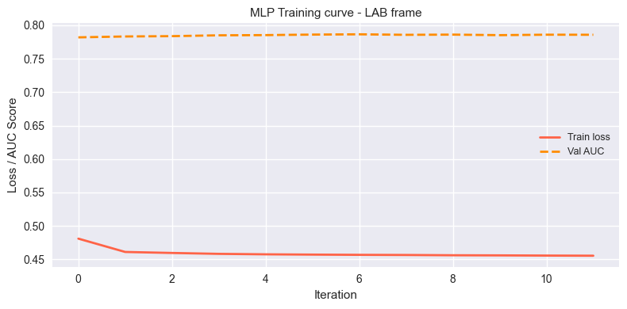

```python
## Neural Network - Lab Frame

mlp_lab = MLPClassifier(
    hidden_layer_sizes=(64, 32, 16),
    activation='relu',
    solver='adam',
    alpha=1e-4,
    batch_size=1024,
    learning_rate='adaptive',
    learning_rate_init=1e-3,
    max_iter=15,
    early_stopping=True,
    validation_fraction=0.10,
    n_iter_no_change=4,
    random_state=RANDOM_SEED,
    verbose=False,
)

t0 = time.time()
mlp_lab.fit(Xtr_lab_sc, y_tr)
print(f"Converged after ({time.time()-t0:.1f}s)\n")

prob_mlp_lab  = mlp_lab.predict_proba(Xte_lab_sc)[:, 1]
yhat_mlp_lab  = mlp_lab.predict(Xte_lab_sc)

auc_mlp_lab  = roc_auc_score(y_te, prob_mlp_lab)
acc_mlp_lab  = accuracy_score(y_te, yhat_mlp_lab)
f1_mlp_lab   = f1_score(y_te, yhat_mlp_lab)
prec_mlp_lab = precision_score(y_te, yhat_mlp_lab)
rec_mlp_lab  = recall_score(y_te, yhat_mlp_lab)

metrics_mlp_lab = dict(AUC=auc_mlp_lab, Accuracy=acc_mlp_lab,
                        F1=f1_mlp_lab, Precision=prec_mlp_lab, Recall=rec_mlp_lab)

print(f"  MLP (LAB)    AUC={auc_mlp_lab:.4f}  Acc={acc_mlp_lab:.4f}  F1={f1_mlp_lab:.4f}  Prec={prec_mlp_lab:.4f}  Rec={rec_mlp_lab:.4f}")

fig, ax = plt.subplots(figsize=(8, 4))
ax.plot(mlp_lab.loss_curve_,         color='tomato',     lw=2, label='Train loss')
ax.plot(mlp_lab.validation_scores_,  color='darkorange', lw=2, linestyle='--',
        label='Val AUC')
ax.set_xlabel('Iteration', fontsize=11)
ax.set_ylabel('Loss / AUC Score', fontsize=11)
ax.set_title('MLP Training curve - LAB frame', fontsize=11)
ax.legend(fontsize=9)
fig.tight_layout()
plt.show()
```

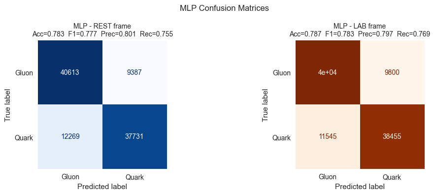

```python
## Confusion Matrices

fig, axes = plt.subplots(1, 2, figsize=(11, 4))

for ax, (frame_label, yhat, mdict, cmap) in zip(axes, [
    ('REST', yhat_mlp_rf,  metrics_mlp_rf,  'Blues'),
    ('LAB',  yhat_mlp_lab, metrics_mlp_lab, 'Oranges'),
]):
    cm   = confusion_matrix(y_te, yhat)
    disp = ConfusionMatrixDisplay(confusion_matrix=cm,
                                  display_labels=['Gluon', 'Quark'])
    disp.plot(ax=ax, colorbar=False, cmap=cmap)
    m = mdict
    ax.set_title(
        f'MLP - {frame_label} frame\n'
        f'Acc={m["Accuracy"]:.3f}  F1={m["F1"]:.3f}  '
        f'Prec={m["Precision"]:.3f}  Rec={m["Recall"]:.3f}',
        fontsize=10
    )
    ax.grid(False)

fig.suptitle('MLP Confusion Matrices', fontsize=12)
fig.tight_layout()
plt.show()
```

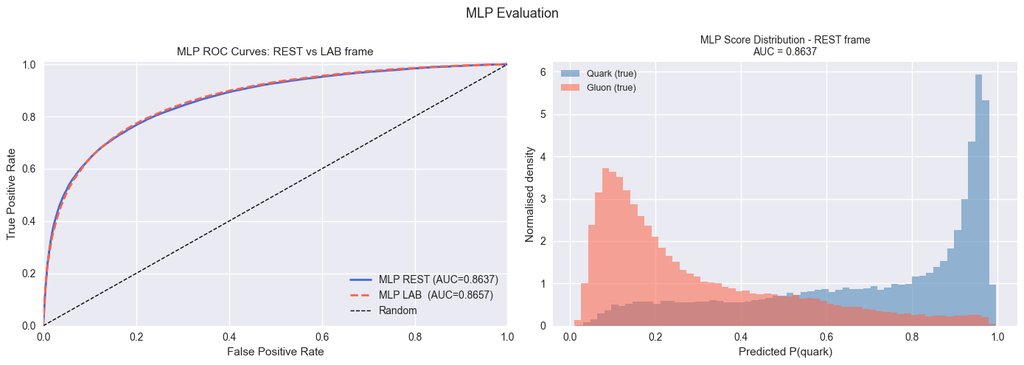

```python
## MLP ROC curves, score distributions

fig, axes = plt.subplots(1, 2, figsize=(14, 5))

ax = axes[0]
fpr_r, tpr_r, _ = roc_curve(y_te, prob_mlp_rf)
fpr_l, tpr_l, _ = roc_curve(y_te, prob_mlp_lab)
ax.plot(fpr_r, tpr_r, '-',  color='royalblue', lw=2,
        label=f'MLP REST (AUC={auc_mlp_rf:.4f})')
ax.plot(fpr_l, tpr_l, '--', color='tomato',    lw=2,
        label=f'MLP LAB  (AUC={auc_mlp_lab:.4f})')
ax.plot([0, 1], [0, 1], 'k--', lw=1, label='Random')
ax.set_xlabel('False Positive Rate', fontsize=11)
ax.set_ylabel('True Positive Rate', fontsize=11)
ax.set_title('MLP ROC Curves: REST vs LAB frame', fontsize=11)
ax.legend(fontsize=10)
ax.set_xlim(0, 1); ax.set_ylim(0, 1.01)

ax2 = axes[1]
ax2.hist(prob_mlp_rf[y_te == 1], bins=60, density=True, alpha=0.55,
         color=QUARK_COLOR, label='Quark (true)')
ax2.hist(prob_mlp_rf[y_te == 0], bins=60, density=True, alpha=0.55,
         color=GLUON_COLOR, label='Gluon (true)')
ax2.set_xlabel('Predicted P(quark)', fontsize=11)
ax2.set_ylabel('Normalised density', fontsize=11)
ax2.set_title(f'MLP Score Distribution - REST frame\nAUC = {auc_mlp_rf:.4f}',
              fontsize=10)
ax2.legend(fontsize=9)

fig.suptitle('MLP Evaluation', fontsize=13)
fig.tight_layout()
plt.show()
```

## Rest Frame vs. Lab Frame

Across all classifiers (Gradient Boosting, Random Forest, Logistic Regression, MLP), the AUC scores in the rest frame and lab frame are nearly identical, differing by at most a few units in the third decimal place. The dominant feature throughout is constituent multiplicity $N$, which is Lorentz-invariant and thus frame-independent by construction. Jet mass and $p_T^D$ are similarly invariant.

The rest-frame feature set adds two variables: sphericity and aplanarity that have no direct lab-frame equivalent. These contribute modestly to classifier performance on top of multiplicity, but their incremental gain is small because the bulk of the discriminating information is already captured by $N$ alone.

The conclusion is that working in the rest frame makes no meaningful difference for the classifiers trained here. The performance ceiling is set by the amount of information in the chosen feature set, not the reference frame, because all frame-sensitive information cancels when constructing the scalars used as inputs. A rest-frame advantage would be expected only if the classifier consumed the raw constituent four-momenta directly, where eliminating the longitudinal boost could reduce the variance the network needs to learn. For hand-engineered scalar features of the type used here, the lab frame and rest frame yield equivalent classification power.

## References

1. Dataset: https://zenodo.org/records/3164691
2. Book: https://etpwww.etp.kit.edu/~rabbertz/Lehre/ParticlePhysics-II_Top-Quarks_and_Jets_at_the_LHC/Literature/Jet-Physics-at-the-LHC_KlausRabbertz.pdf (I don't have a background in particle physics, so refered this to verify definitions and formulas)
3. Paper: https://arxiv.org/pdf/1211.7038 (A reference paper to know more about Quark and Gluon jets)
4. PDG IDs: https://pdg.lbl.gov/2007/reviews/montecarlorpp.pdf

Currently, as a part of the evalutation test, I've trained the a few rudimentary classifiers and MLP based simple neural networks. For further explorations, I'll be trying out these implementation approaches:

- Efficient Lorentz Equivariant Graph Neural Network (https://arxiv.org/abs/2201.08187)
- ParticleNet (https://arxiv.org/abs/1902.08570)